# Best books of all times

Marian Nehrebecki, Aleksander Partyga, Magdalena Sobala

06 czerwiec, 2022

### Overview

(From the [Goodreads](https://www.goodreads.com)) Goodreads.com is the world’s largest site for readers and book recommendations. The mission of Goodreads is to help people find and share books they love.

### A few things we can do on Goodreads

> - See what books our friends are reading.
> - Track the books we’ re reading, have read, and want to read.
> - Check out our personalized book recommendations. The recommendation engine analyzes 20 billion data points to give suggestions tailored to our literary tastes.
> - Find out if a book is a good fit for us from our community’s reviews.

## Summary of the best books of all time

In total, we gathered available data from [Best Books By Century](https://www.goodreads.com/list/show/7), namely 19471 unique book titles along with their:

- author
- total score (which is based on number of votes and and how highly those voters ranked the book)
- URL link
- average rating
- number of times rated

## Visualisations:

### Books that were rated the most times

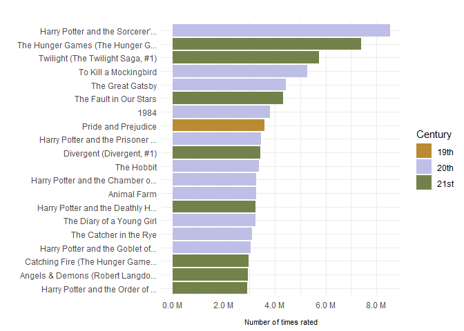

The book that was rated the most times is “**Harry Potter and the Sorcerer’s Stone (Harry Potter, #1)**” written by **J.K. Rowling** which was rated **8525498** number of times.

### Books with the highest total scores

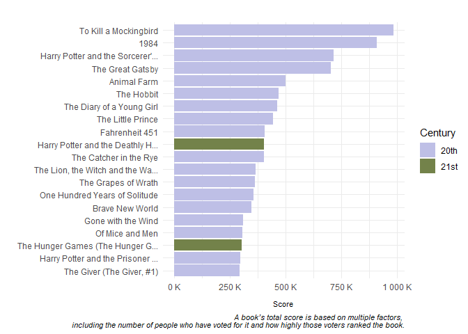

The top rated book of all time is “**To Kill a Mockingbird**” which was rated **5277975** number of times and received an average rating of **4.27**.

### Most prolific authors

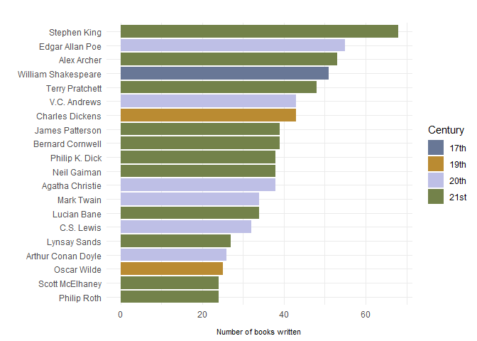

**Stephen King** is the author who has written the most books (**68**) that were present in the Best Books by Century on Goodreads.